# Some Results from the UNOS Data

Fan Wu

2016-11-16

## Data Manipulation

- first start with dialysis but have no dialysis modality recorded (7%)
- first start with dialysis but have unknown dialysis modality (3%)
- first start with dialysis and change the modality of dialysis before TX (3%)
- first start with dialysis but have no dialysis date recorded (15%)

We allow the renal replacement therapy of a patient change during the follow up, from dialysis to TX after receiving an allograft, or from TX to dialysis following the allograft failure and he/her is on dialysis again. Thus, the treatment is a **time-dependent** covariate.

We also adjusted for age at ESRD onset (centered and scaled using the mean and SD of the ages), gender and race.

The number of patients, number of events, and censoring rates for each included states are as follows:

|  | n.Patients | n.Deaths | cens.rate |
| --- | --- | --- | --- |
| CA | 2912 | 861 | 70.4 |
| TX | 1782 | 513 | 71.2 |
| NY | 1597 | 512 | 67.9 |
| PA | 1203 | 464 | 61.4 |
| FL | 1040 | 333 | 68.0 |
| IL | 971 | 349 | 64.1 |
| MI | 783 | 304 | 61.2 |
| OH | 769 | 279 | 63.7 |
| VA | 653 | 271 | 58.5 |
| NC | 549 | 171 | 68.9 |
| TN | 516 | 177 | 65.7 |
| AL | 495 | 218 | 56.0 |
| GA | 483 | 148 | 69.4 |
| MN | 482 | 155 | 67.8 |
| NJ | 476 | 174 | 63.4 |
| AZ | 432 | 124 | 71.3 |
| MA | 432 | 155 | 64.1 |
| MO | 430 | 127 | 70.5 |
| MD | 376 | 131 | 65.2 |
| WI | 347 | 113 | 67.4 |
| LA | 329 | 110 | 66.6 |
| IN | 322 | 101 | 68.6 |
| CO | 284 | 105 | 63.0 |
| WA | 278 | 79 | 71.6 |
| DC | 254 | 77 | 69.7 |
| OR | 209 | 70 | 66.5 |
| KY | 183 | 68 | 62.8 |
| OK | 140 | 58 | 58.6 |
| SC | 140 | 45 | 67.9 |
| AR | 137 | 52 | 62.0 |
| UT | 137 | 31 | 77.4 |
| NE | 136 | 45 | 66.9 |
| CT | 119 | 34 | 71.4 |
| IA | 119 | 44 | 63.0 |
| KS | 103 | 31 | 69.9 |
| NM | 84 | 28 | 66.7 |
| NV | 81 | 26 | 67.9 |
| ME | 69 | 23 | 66.7 |
| ND | 66 | 20 | 69.7 |
| WV | 62 | 29 | 53.2 |
| HI | 55 | 13 | 76.4 |
| SD | 43 | 19 | 55.8 |
| MS | 42 | 15 | 64.3 |

## Estimate of the PD and TX log Hazards

(pdf)

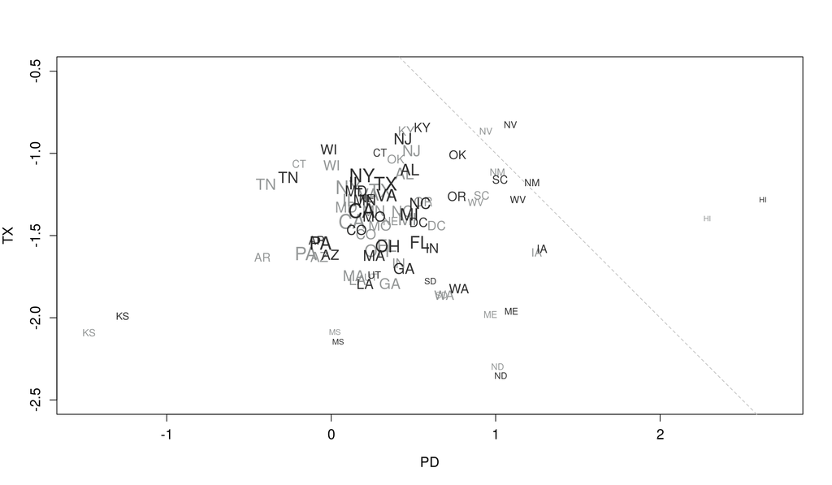

## Compare SEs using Conditional vs PLAC

(pdf)

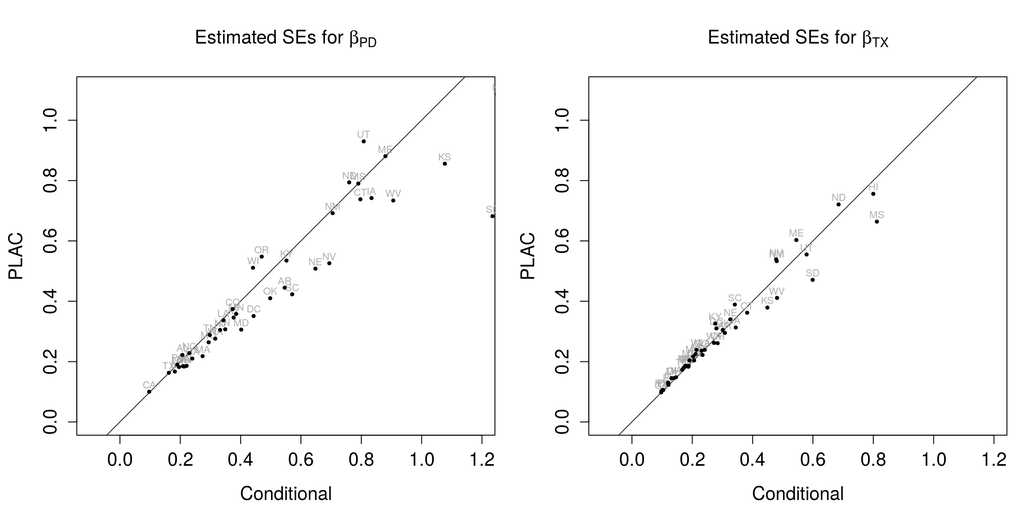

## Compare Ratio of Variances using Conditional vs PLAC

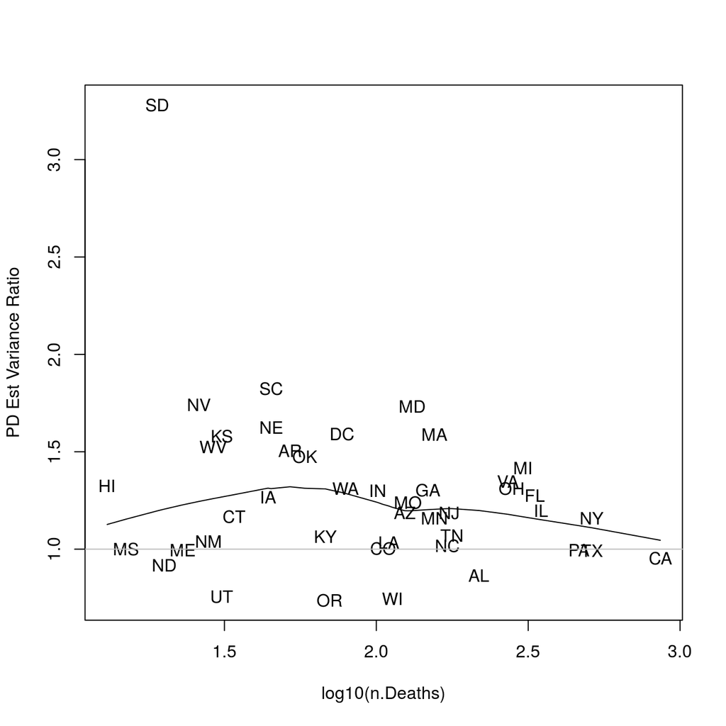

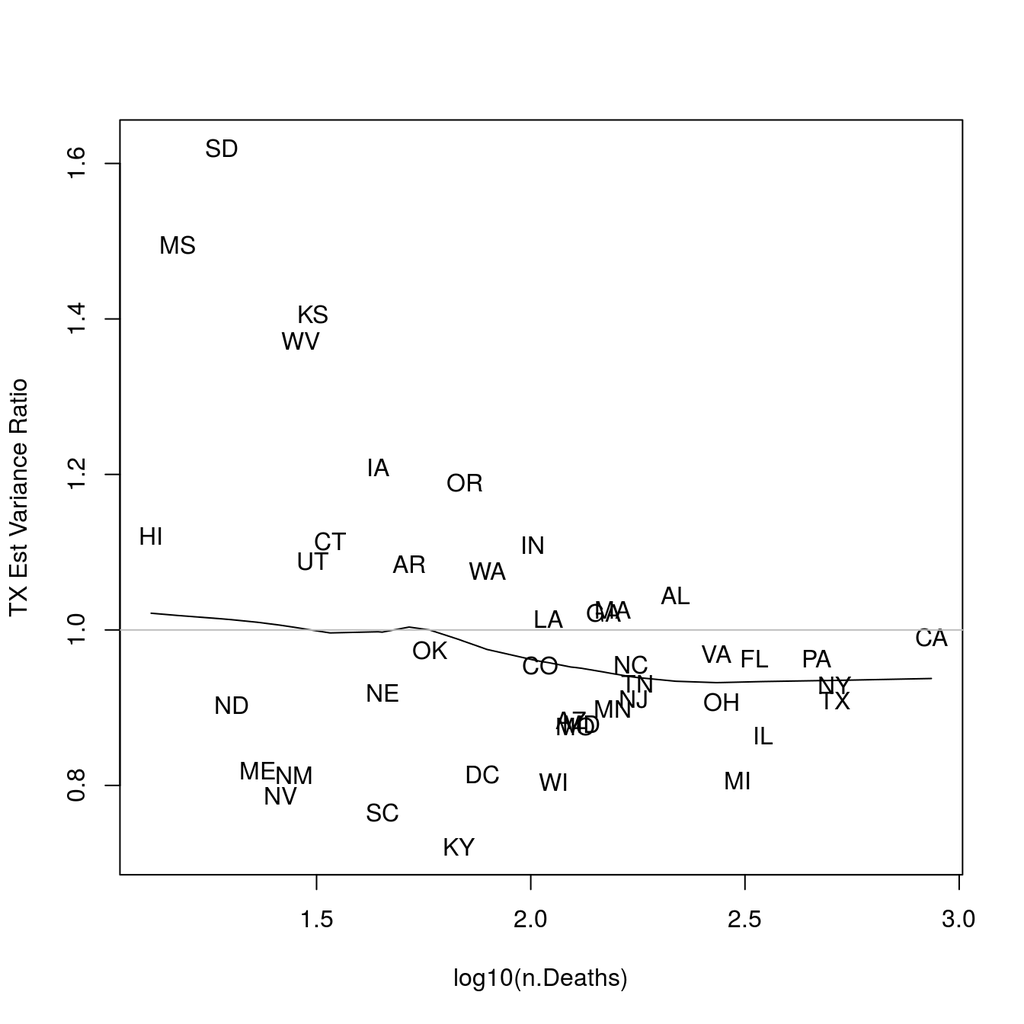

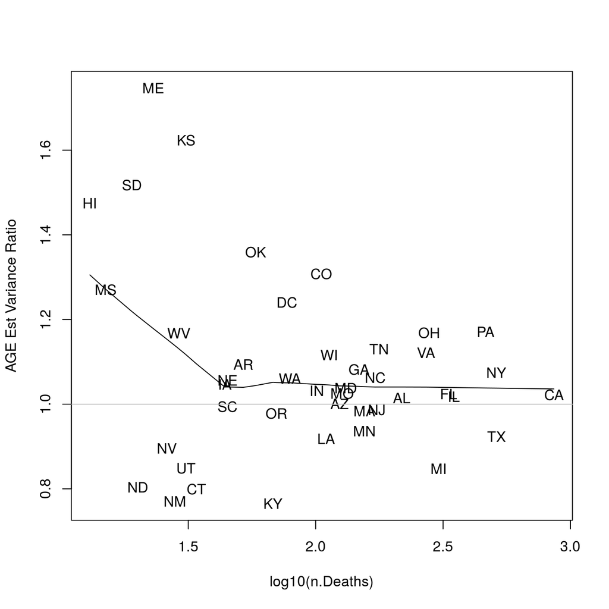

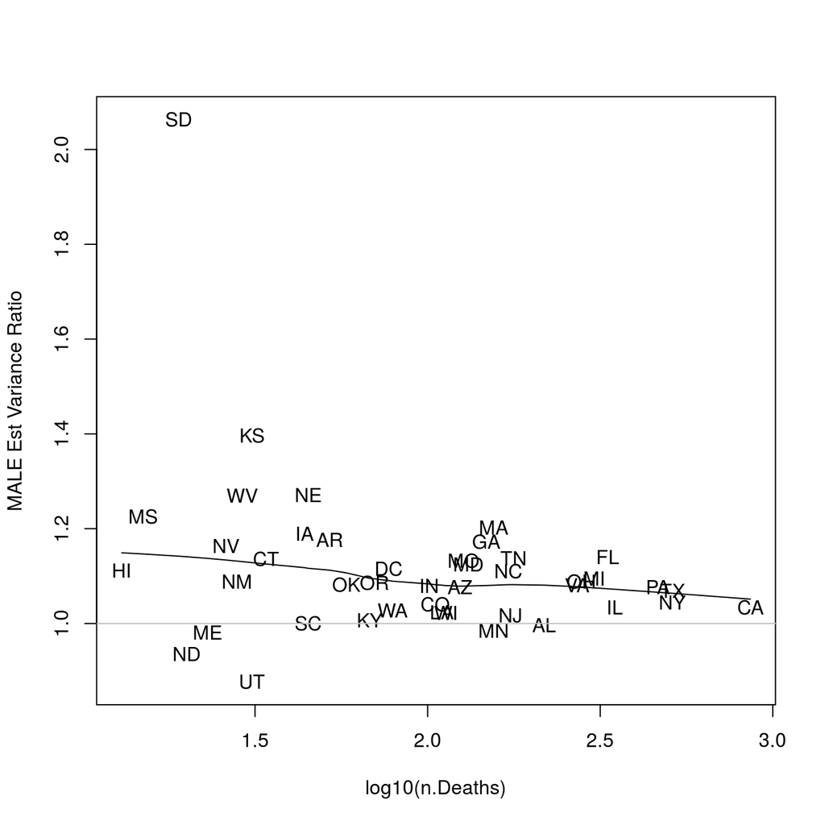

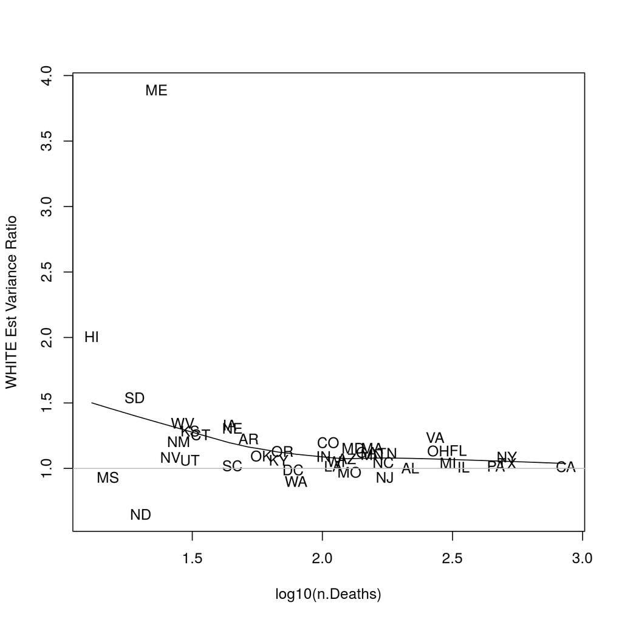

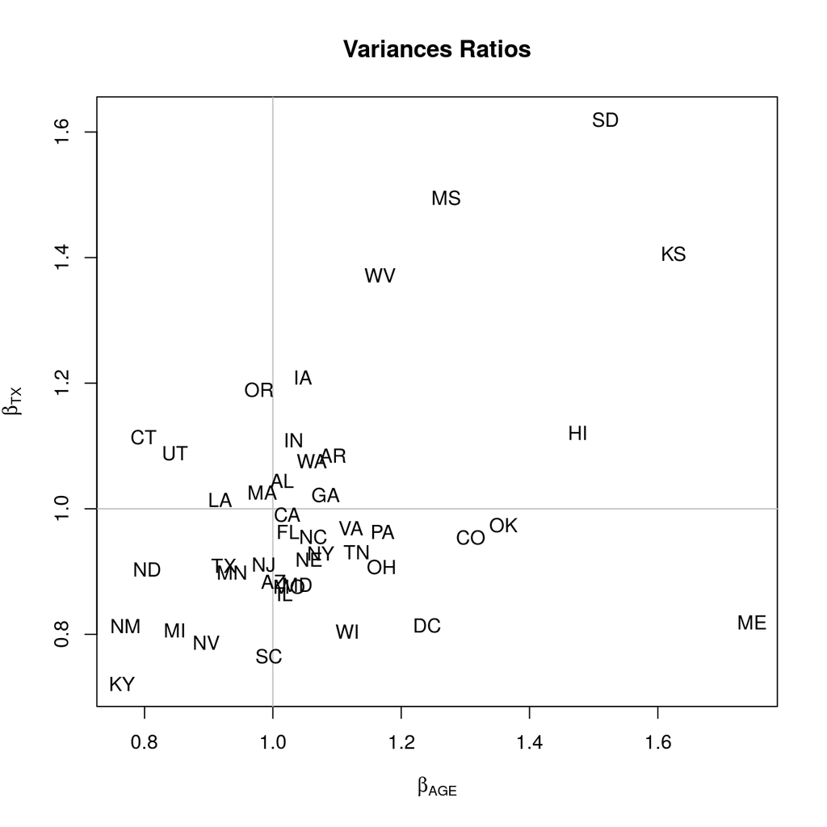

## Christmas Trees

(pdf)

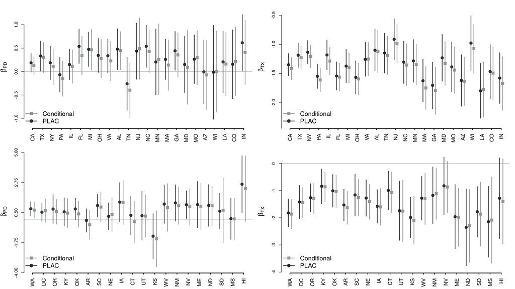

## Maps

We are working on some states maps to show the magnitudes of the $\beta_{PD}$ and $\beta_{TX}$ in gradient.

```
## [1] "PD.Effect"
```

```
##     AL     AR     AZ     CA     CO     CT     DC     FL     GA     HI
##  0.477 -0.090 -0.007  0.186  0.154  0.297  0.531  0.537  0.442  2.624
##     IA     IL     IN     KS     KY     LA     MA     MD     ME     MI
##  1.283  0.150  0.613 -1.269  0.554  0.206  0.260  0.151  1.096  0.474
##     MN     MO     MS     NC     ND     NE     NJ     NM     NV     NY
##  0.204  0.262  0.042  0.539  1.032  0.215  0.435  1.222  1.089  0.188
##     OH     OK     OR     PA     SC     SD     TN     TX     UT     VA
##  0.344  0.769  0.764 -0.067  1.026  0.603 -0.261  0.331  0.263  0.336
##     WA     WI     WV
##  0.778 -0.015  1.134
```

```
##    20%    40%    60%    80%   100%
## 0.1522 0.2628 0.4878 0.7744 2.6240
```

```
## [1] "TX.Effect"
```

```
##     AL     AR     AZ     CA     CO     CT     DC     FL     GA     HI
## -1.098 -1.530 -1.617 -1.348 -1.466 -0.995 -1.420 -1.540 -1.701 -1.283
##     IA     IL     IN     KS     KY     LA     MA     MD     ME     MI
## -1.580 -1.180 -1.576 -1.989 -0.842 -1.794 -1.622 -1.229 -1.961 -1.370
##     MN     MO     MS     NC     ND     NE     NJ     NM     NV     NY
## -1.282 -1.385 -2.145 -1.305 -2.352 -1.274 -0.911 -1.177 -0.825 -1.134
##     OH     OK     OR     PA     SC     SD     TN     TX     UT     VA
## -1.564 -1.008 -1.261 -1.545 -1.160 -1.777 -1.146 -1.184 -1.741 -1.255
##     WA     WI     WV
## -1.824 -0.976 -1.280
```

```
##     20%     40%     60%     80%    100%
## -1.6694 -1.4788 -1.2788 -1.1516 -0.8250
```

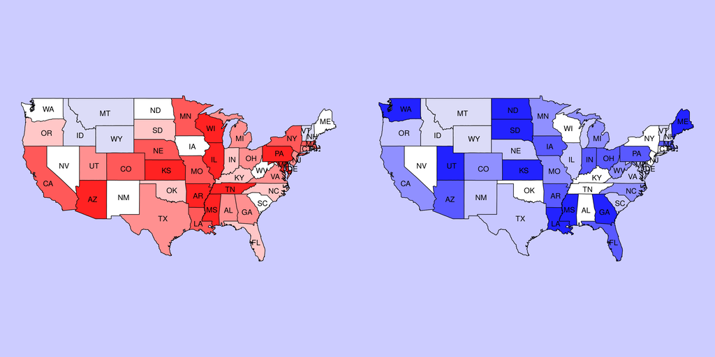

## To Make the Analysis Great Again

- Change the time point of switching the “on-going” treatment (e.g., 60 days after the switch)
- Consider the time-varying treatment effect?
- Find several *typical* states where the proposed method performs well